# Homework 2

Meng-Wei Wu, Yifan Cai, Chi-En Hwang, Yashi Tiwari, Parina Kolhe

2023-03-04

```r
library(fpp3)
library(stats)
library(tsibbledata)
library(dplyr)
```

## 5.11 Exercise – Problem 7

## For your retail time series (from Exercise 8 in Section 2.10):

### a. Create a training dataset consisting of observations before 2011

```r
set.seed(1)
aus_retail <- aus_retail
myseries <- aus_retail %>%
  filter(`Series ID` == sample(aus_retail$`Series ID`, 1))

myseries_train <- myseries %>%
  filter(year(Month) < 2011)
```

### b. Check that your data have been split appropriately by producing the following plot.

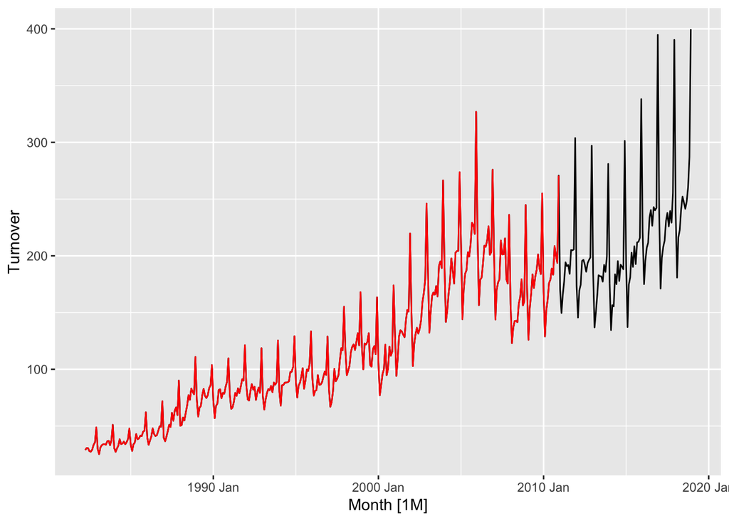

```r
autoplot(myseries, Turnover) +
  autolayer(myseries_train, Turnover, colour = "red")
```

### c. Fit a seasonal naïve model using SNAIVE() applied to your training data (myseries_train).

```r
fit <- myseries_train %>%
  model(SNAIVE(Turnover))
```

### d. Check the residuals. Do the residuals appear to be uncorrelated and normally distributed?

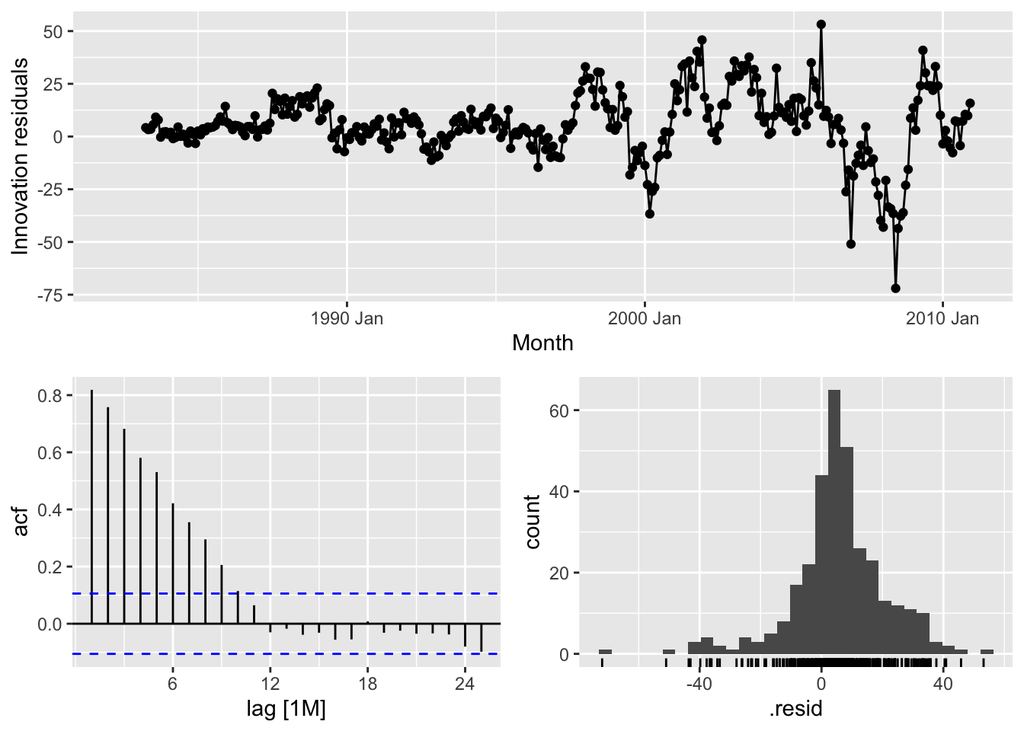

```r
fit %>% gg_tsresiduals()
```

#### Comment

The mean of the residuals is not close to zero and there is significant correlations in the residuals series. The time plot of residuals shows that the variation of the residuals does not stay around the same across historical data after 2000 and therefore the residual variance may not be constant. The histogram suggests that the residuals may not be normal because the left tail seems a little too long. In sum, the forecasts and prediction intervals from this method may be inaccurate.

### e. Produce forecasts for the test data.

```r
forecast <- fit %>%
  forecast(new_data = anti_join(myseries, myseries_train))
```

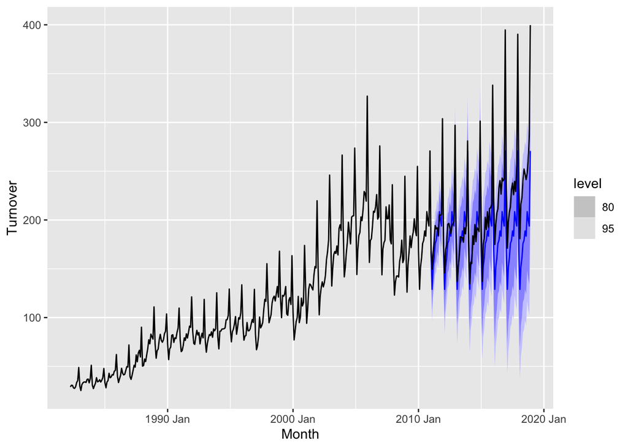

```r
forecast %>% autoplot(myseries)
```

### f. Compare the accuracy of your forecasts against the actual values.

```r
fit %>% accuracy()
```

```
## # A tibble: 1 × 12
##   State    Industry .model .type    ME  RMSE   MAE   MPE  MAPE  MASE RMSSE  ACF1
##   <chr>    <chr>    <chr>  <chr> <dbl> <dbl> <dbl> <dbl> <dbl> <dbl> <dbl> <dbl>
## 1 Queensl… Clothin… SNAIV… Trai…  5.50  16.5  12.1  5.39  10.6     1     1 0.819
```

```r
forecast %>% accuracy(myseries)
```

```
## # A tibble: 1 × 12
##   .model    State Industry .type    ME  RMSE   MAE   MPE  MAPE  MASE RMSSE  ACF1
##   <chr>     <chr> <chr>    <chr> <dbl> <dbl> <dbl> <dbl> <dbl> <dbl> <dbl> <dbl>
## 1 SNAIVE(T… Quee… Clothin… Test   26.9  40.2  29.3  11.3  12.6  2.43  2.44 0.752
```

### g. How sensitive are the accuracy measures to the amount of training data used?

Accuracy measures are sensitive to the size of training data used in the model. With a larger proportion of training data, the accuracy will increase. However, we should still use cross validation or other similar techniques to avoid the overfitting problem and to make the model more robust.